# Effects of different indicators on the duration of the trip

## by Hadil Jilani

## Investigation Overview

In this investigation, I want to look at the indicators of the trip that could be used to predict the average duration. The main focus was on the user type, user gender and the hour of the day the trip started.

## Dataset Overview

This data set includes information about approximately 183000 individual rides made in a bike-sharing system covering the greater San Francisco Bay area. It includes features such as the start- and end-times, start- and end-locations, duration and information about the user such as their type, gender, year of birth etc..

## Distribution of Trip Durations

Trip durations in the dataset take on a very large range of values, from about *60 sec (1 min)*, to about *84000 sec (23 hours)*. Plotted on a logarithmic scale, the distribution of trip durations takes on a unimodal shape.

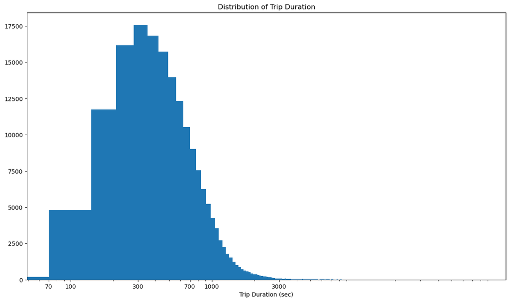

## Distribution of the User Types

User of the bike sharing system are divided into two categories: *Customer* and *Subscriber*. The relative frequency distribution shows that **subscribers** have the majority with *91%* of trips, whilst the **customers** only occupy *9%*.

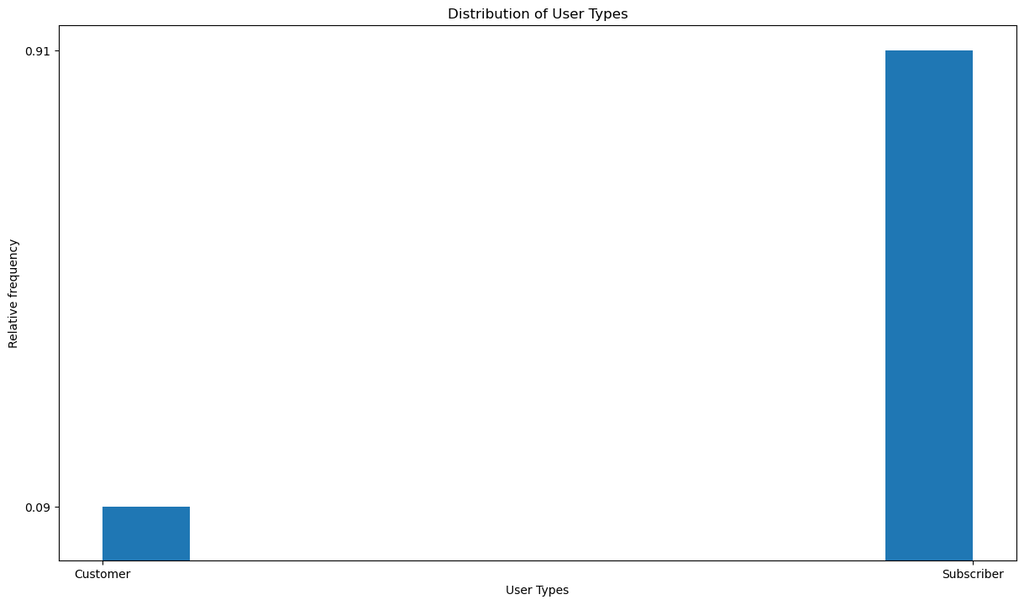

## Distribution of Member Genders

Genders of users present in this dataset are *male*, *female* and *others*. The relative frequency distribution shows that **male** users have the majority with *75%* of trips, whilst the **female** only occupy *23%* and **other genders** *2%*.

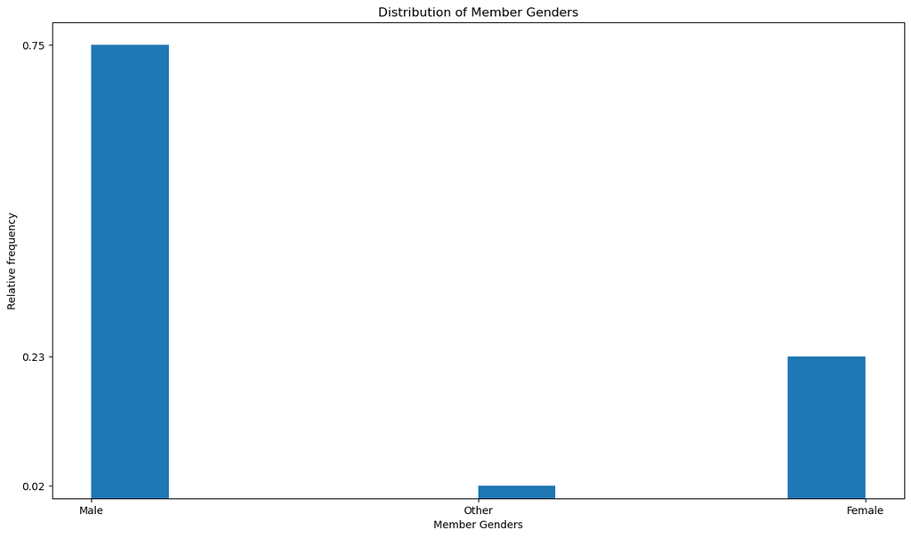

## Duration by Hour and User Type

We can see that when it comes to average duration, **customers** tend to have higher average durations than the **subscribers**. There is a particular peak between *1 am* and *4 am* fo both plots. This may indicate that the average duration will rise in this time of the day *independently*of the user type

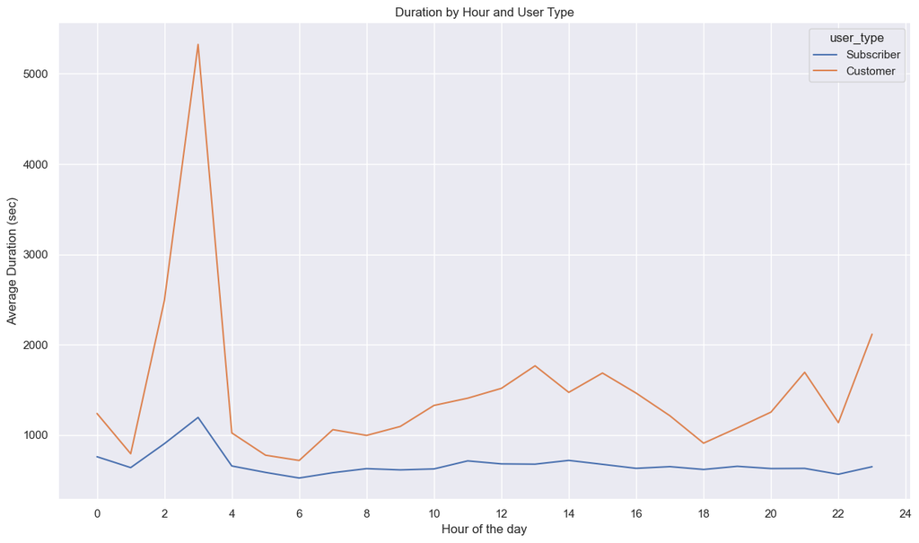

## Duration by Hour and Member Genders

Reproducing the same plot with gender instead of user type shows that the the particular peak is still there, with similar behaviour on the rest of the day (except for the other genders as there are local peaks after the bigger one). This only confirms that hour is a strong predictor of the direction of variation of the average duration plot. The values it will take can be predicted by the gender and the type of the users.

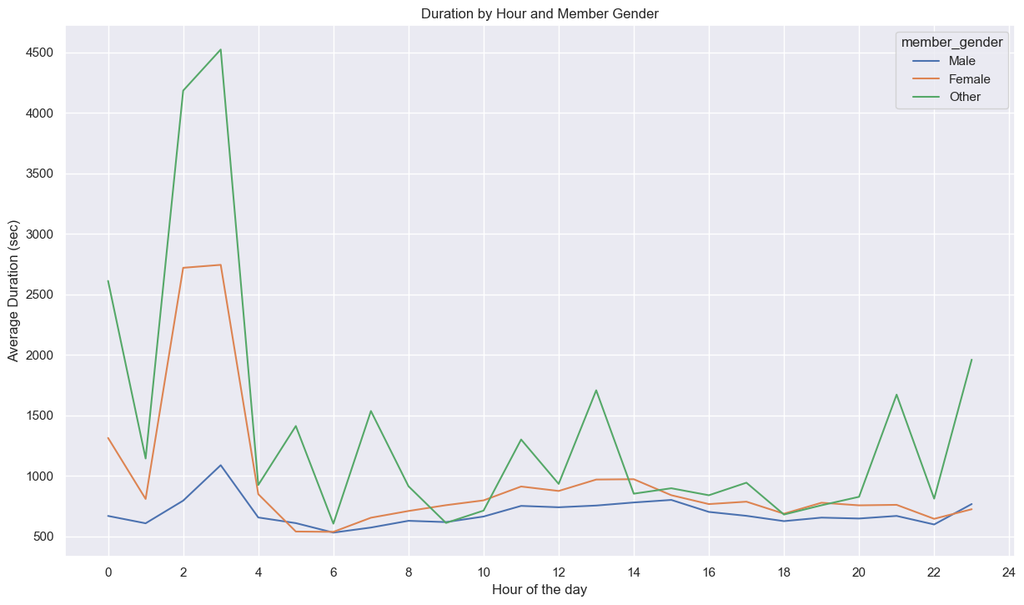